# 2U Challenge

Stefan Fouche

```r
py_config()
```

```
python:         /opt/conda/envs/baseline/bin/python
libpython:      /opt/conda/envs/baseline/lib/libpython3.7m.so
pythonhome:     /opt/conda/envs/baseline:/opt/conda/envs/baseline
version:        3.7.4 (default, Aug 13 2019, 20:35:49)  [GCC 7.3.0]
numpy:          /opt/conda/envs/baseline/lib/python3.7/site-packages/numpy
numpy_version:  1.16.4

NOTE: Python version was forced by RETICULATE_PYTHON
```

```python
import pandas as pd
```

## Load and validate data

Validate format of data

```bash
head -n 10 ../data/raw/*.csv
```

```
==> ../data/raw/ticket_data201803 (1) (1).csv <==
ticket_id,status,priority,source,group,created_time,resolved_time,initial_time,agent_interactions,customer_interactions,type,course,user_id,agent_id
2009687,Closed,Low,Email,Student Records,2018-03-05 19:11,2018-03-06 09:22,2018-03-05 21:41,3,1,Student Records Task,NA,1454,2
2139362,Closed,Urgent,Email,Student Records,2018-03-28 12:51,2018-04-03 07:30,2018-03-28 13:11,3,2,Student Records Task,USB,2960,2
2141198,Closed,Low,Email,Student Records,2018-03-28 17:48,2018-03-29 08:20,2018-03-29 08:19,1,2,NetVerify,NA,411,2
2148810,Closed,Urgent,Email,Student Records,2018-03-30 07:32,2018-04-04 07:34,2018-03-30 18:10,4,3,Student Records Task,MIT-AI-2018-01-31,643,2
2113936,Closed,Low,Email,Student Records,2018-03-23 14:45,2018-03-23 15:08,2018-03-23 15:08,1,1,Student Records Task,NA,2891,2
2047999,Closed,Urgent,Email,Student Records,2018-03-12 11:58,2018-03-12 14:00,2018-03-12 12:16,1,1,Student Records Task,NA,2722,2
2142438,Closed,Urgent,Email,Student Records,2018-03-28 22:56,2018-04-03 07:52,2018-03-29 08:03,2,2,NetVerify,NA,809,2
2069426,Closed,Low,Email,Student Records,2018-03-15 16:15,2018-03-15 16:25,2018-03-15 16:20,2,2,Student Records Task,NA,2486,2
2005913,Closed,Urgent,Email,Student Records,2018-03-05 11:02,2018-03-05 13:15,2018-03-05 11:33,2,2,Student Records Task,NA,2736,2

==> ../data/raw/top_10_MIT_AI_2018_01_31 (1) (1).csv <==
user_id
882
910
1012
1018
1025
1029
1048
1064
1098
```

Nothing seems odd about the downloaded data

### Explore data

Before we start it’s usually a good idea to get a feel for the data…

Read in the ticket data

```r
ticket_data201803 = data.table::fread("../data/raw/ticket_data201803 (1) (1).csv")
ticket_data201803
```

| ticket_id | status | priority | source | group | created_time | resolved_time | initial_time | agent_interactions | customer_interactions | type | course | user_id | agent_id |
| --- | --- | --- | --- | --- | --- | --- | --- | --- | --- | --- | --- | --- | --- |
| 2009687 | Closed | Low | Email | Student Records | 2018-03-05 19:11 | 2018-03-06 09:22 | 2018-03-05 21:41 | 3 | 1 | Student Records Task | NA | 1454 | 2 |
| 2139362 | Closed | Urgent | Email | Student Records | 2018-03-28 12:51 | 2018-04-03 07:30 | 2018-03-28 13:11 | 3 | 2 | Student Records Task | USB | 2960 | 2 |
| 2141198 | Closed | Low | Email | Student Records | 2018-03-28 17:48 | 2018-03-29 08:20 | 2018-03-29 08:19 | 1 | 2 | NetVerify | NA | 411 | 2 |
| 2148810 | Closed | Urgent | Email | Student Records | 2018-03-30 07:32 | 2018-04-04 07:34 | 2018-03-30 18:10 | 4 | 3 | Student Records Task | MIT-AI-2018-01-31 | 643 | 2 |
| 2113936 | Closed | Low | Email | Student Records | 2018-03-23 14:45 | 2018-03-23 15:08 | 2018-03-23 15:08 | 1 | 1 | Student Records Task | NA | 2891 | 2 |
| 2047999 | Closed | Urgent | Email | Student Records | 2018-03-12 11:58 | 2018-03-12 14:00 | 2018-03-12 12:16 | 1 | 1 | Student Records Task | NA | 2722 | 2 |
| 2142438 | Closed | Urgent | Email | Student Records | 2018-03-28 22:56 | 2018-04-03 07:52 | 2018-03-29 08:03 | 2 | 2 | NetVerify | NA | 809 | 2 |
| 2069426 | Closed | Low | Email | Student Records | 2018-03-15 16:15 | 2018-03-15 16:25 | 2018-03-15 16:20 | 2 | 2 | Student Records Task | NA | 2486 | 2 |
| 2005913 | Closed | Urgent | Email | Student Records | 2018-03-05 11:02 | 2018-03-05 13:15 | 2018-03-05 11:33 | 2 | 2 | Student Records Task | NA | 2736 | 2 |
| 2085757 | Closed | Urgent | Outbound Email | Student Records | 2018-03-19 09:29 | 2018-04-09 08:40 | 2018-03-19 09:47 | 3 | 3 | Student Records Task | NA | 3005 | 2 |

[output cut: 990 more lines]

There might be some trouble down the line with character NA’s, Ordinal vs Nominal features encoded as pure character strings and also the date time fields not ecoded as date time format.

Create in memory pointer for database and write table

```r
con <- DBI::dbConnect(RSQLite::SQLite(), ":memory:")
DBI::dbWriteTable(con, "tickets", ticket_data201803)
```

Check data type stability from database

```r
tickets_tbl = tbl(con, sql('select * from tickets'))

tickets_tbl
```

| ticket_id | status | priority | source | group | created_time | resolved_time | initial_time | agent_interactions | customer_interactions | type | course | user_id | agent_id |
| --- | --- | --- | --- | --- | --- | --- | --- | --- | --- | --- | --- | --- | --- |
| 2009687 | Closed | Low | Email | Student Records | 2018-03-05 19:11 | 2018-03-06 09:22 | 2018-03-05 21:41 | 3 | 1 | Student Records Task | NA | 1454 | 2 |
| 2139362 | Closed | Urgent | Email | Student Records | 2018-03-28 12:51 | 2018-04-03 07:30 | 2018-03-28 13:11 | 3 | 2 | Student Records Task | USB | 2960 | 2 |
| 2141198 | Closed | Low | Email | Student Records | 2018-03-28 17:48 | 2018-03-29 08:20 | 2018-03-29 08:19 | 1 | 2 | NetVerify | NA | 411 | 2 |
| 2148810 | Closed | Urgent | Email | Student Records | 2018-03-30 07:32 | 2018-04-04 07:34 | 2018-03-30 18:10 | 4 | 3 | Student Records Task | MIT-AI-2018-01-31 | 643 | 2 |
| 2113936 | Closed | Low | Email | Student Records | 2018-03-23 14:45 | 2018-03-23 15:08 | 2018-03-23 15:08 | 1 | 1 | Student Records Task | NA | 2891 | 2 |
| 2047999 | Closed | Urgent | Email | Student Records | 2018-03-12 11:58 | 2018-03-12 14:00 | 2018-03-12 12:16 | 1 | 1 | Student Records Task | NA | 2722 | 2 |
| 2142438 | Closed | Urgent | Email | Student Records | 2018-03-28 22:56 | 2018-04-03 07:52 | 2018-03-29 08:03 | 2 | 2 | NetVerify | NA | 809 | 2 |
| 2069426 | Closed | Low | Email | Student Records | 2018-03-15 16:15 | 2018-03-15 16:25 | 2018-03-15 16:20 | 2 | 2 | Student Records Task | NA | 2486 | 2 |
| 2005913 | Closed | Urgent | Email | Student Records | 2018-03-05 11:02 | 2018-03-05 13:15 | 2018-03-05 11:33 | 2 | 2 | Student Records Task | NA | 2736 | 2 |
| 2085757 | Closed | Urgent | Outbound Email | Student Records | 2018-03-19 09:29 | 2018-04-09 08:40 | 2018-03-19 09:47 | 3 | 3 | Student Records Task | NA | 3005 | 2 |

[output cut: 990 more lines]

Remove data frame

```r
rm(ticket_data201803)
```

```
object 'ticket_data201803' not found
```

Now that our data is loaded onto the sqlite DB let’s explore the data a bit

#### Status distribution

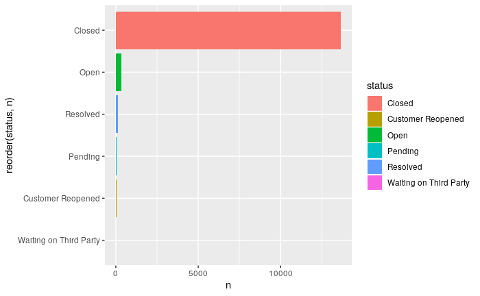

```r
tickets_tbl %>%
  group_by(status) %>%
  tally %>%
  ggplot()+
  geom_bar(aes(x=reorder(status,n),y=n,fill=status),stat = 'identity')+
  coord_flip()
```

#### Priority distribution

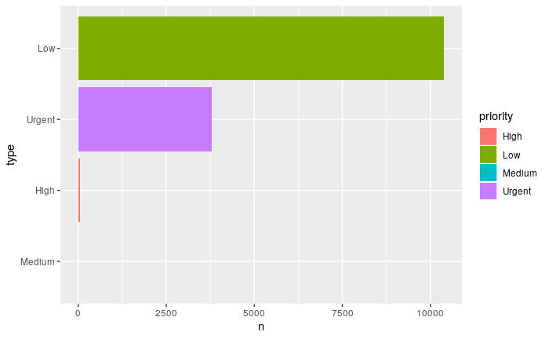

#### Distribution of top 10 type

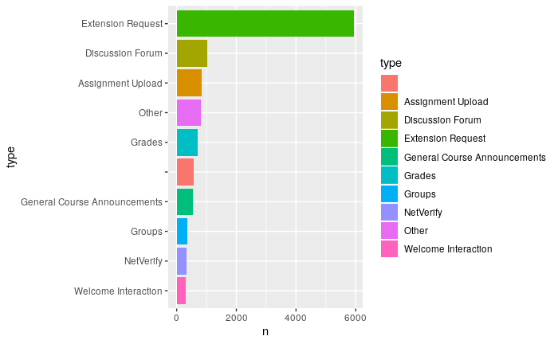

#### Volume over time

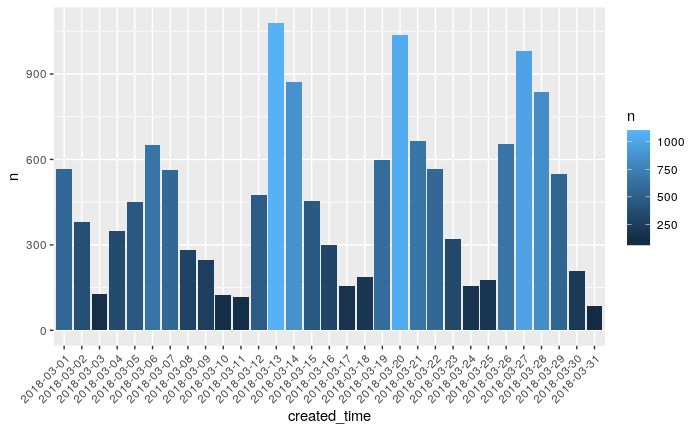

Volume has a weakly seasonality

## SQL test (SQLite3)

Since this is a sql test I will no longer use dbplyr to translate for me. So for simplicity I will just use sql chunks

### Add column to calculate the total seconds it took to resolve the ticket

SQLite isn’t a very good DB so it does not have timestampdiff, I will calculate a days diff and convert it to seconds?

```sql
select
  *,
  (julianday(resolved_time) - julianday(created_time))*24*60*60 as resolved_time_sec
from tickets
```

| ticket_id | status | priority | source | group | created_time | resolved_time | initial_time | agent_interactions | customer_interactions | type | course | user_id | agent_id | resolved_time_sec |
| --- | --- | --- | --- | --- | --- | --- | --- | --- | --- | --- | --- | --- | --- | --- |
| 2009687 | Closed | Low | Email | Student Records | 2018-03-05 19:11 | 2018-03-06 09:22 | 2018-03-05 21:41 | 3 | 1 | Student Records Task | NA | 1454 | 2 | 51060 |
| 2139362 | Closed | Urgent | Email | Student Records | 2018-03-28 12:51 | 2018-04-03 07:30 | 2018-03-28 13:11 | 3 | 2 | Student Records Task | USB | 2960 | 2 | 499140 |
| 2141198 | Closed | Low | Email | Student Records | 2018-03-28 17:48 | 2018-03-29 08:20 | 2018-03-29 08:19 | 1 | 2 | NetVerify | NA | 411 | 2 | 52320 |
| 2148810 | Closed | Urgent | Email | Student Records | 2018-03-30 07:32 | 2018-04-04 07:34 | 2018-03-30 18:10 | 4 | 3 | Student Records Task | MIT-AI-2018-01-31 | 643 | 2 | 432120 |
| 2113936 | Closed | Low | Email | Student Records | 2018-03-23 14:45 | 2018-03-23 15:08 | 2018-03-23 15:08 | 1 | 1 | Student Records Task | NA | 2891 | 2 | 1380 |
| 2047999 | Closed | Urgent | Email | Student Records | 2018-03-12 11:58 | 2018-03-12 14:00 | 2018-03-12 12:16 | 1 | 1 | Student Records Task | NA | 2722 | 2 | 7320 |
| 2142438 | Closed | Urgent | Email | Student Records | 2018-03-28 22:56 | 2018-04-03 07:52 | 2018-03-29 08:03 | 2 | 2 | NetVerify | NA | 809 | 2 | 464160 |
| 2069426 | Closed | Low | Email | Student Records | 2018-03-15 16:15 | 2018-03-15 16:25 | 2018-03-15 16:20 | 2 | 2 | Student Records Task | NA | 2486 | 2 | 600 |
| 2005913 | Closed | Urgent | Email | Student Records | 2018-03-05 11:02 | 2018-03-05 13:15 | 2018-03-05 11:33 | 2 | 2 | Student Records Task | NA | 2736 | 2 | 7980 |
| 2085757 | Closed | Urgent | Outbound Email | Student Records | 2018-03-19 09:29 | 2018-04-09 08:40 | 2018-03-19 09:47 | 3 | 3 | Student Records Task | NA | 3005 | 2 | 1811460 |

[output cut: 990 more lines]

#### Show volume and average resolve time of tickets for each agent

```sql
with resolve_time as (
select
  *,
  (julianday(resolved_time) - julianday(created_time))*24*60*60 as resolved_time_sec
from tickets
)
select
  agent_id,
  count(*) as volume,
  time(avg(resolved_time_sec), 'unixepoch') as avg_resolved_time
from resolve_time
group by agent_id
order by avg_resolved_time
```

| agent_id | volume | avg_resolved_time |
| --- | --- | --- |
| 35 | 2 | NA |
| 45 | 1 | NA |
| 47 | 2 | NA |
| 48 | 1 | NA |
| 33 | 2 | 00:01:00 |
| 49 | 1 | 00:11:00 |
| 34 | 3 | 00:12:20 |
| 37 | 21 | 00:26:57 |
| 43 | 1 | 00:56:00 |
| 23 | 20 | 01:14:06 |

[output cut: 39 more lines]

#### Repeated exactly for type

```sql
with resolve_time as (
select
  *,
  (julianday(resolved_time) - julianday(created_time))*24*60*60 as resolved_time_sec
from tickets
)
select
  type,
  count(*) as volume,
  time(avg(resolved_time_sec), 'unixepoch') as avg_resolved_time
from resolve_time
group by type
order by avg_resolved_time
```

| type | volume | avg_resolved_time |
| --- | --- | --- |
| Student Records Query | 11 | 00:08:10 |
| ID Upload | 4 | 00:37:00 |
| Peer Reviews | 11 | 00:41:27 |
| Certificate Task | 129 | 01:02:48 |
| Scheduled Calls | 3 | 01:35:00 |
| Student Performance Task | 1 | 01:39:00 |
| OLC Navigation | 215 | 02:30:07 |
| Voicemail | 13 | 02:32:09 |
| Student Performance Query | 2 | 03:17:00 |
| Quiz | 50 | 03:28:20 |

[output cut: 45 more lines]

#### Load top 10 AI students data into DB

View the data

```sql
select * from top_ten
```

| user_id |
| --- |
| 882 |
| 910 |
| 1012 |
| 1018 |
| 1025 |
| 1029 |
| 1048 |
| 1064 |
| 1098 |
| 1161 |

#### Type and number of agent interactions of the last observed interaction for top 10 students

I’m not sure what `interaction` is per se. Since it could be any one of the 3 time stamps (if others are not populated for example) I will need to calculate the max over the row to find the max interaction of that row and then for each student find that ticket that corresponds to the max of those max…

There’s probably a more succinct way of doing this but w/e

```sql
with calc_interaction as (
  select
    a.user_id,
    max(created_time,resolved_time,initial_time) as max_interaction,
    type,
    agent_interactions
  from tickets a
  inner join top_ten b
  on a.user_id = b.user_id
), per_user_max as (
  select
    *,
    max(max_interaction) over (partition by user_id) as user_max_interaction
  from calc_interaction
)
select
    user_id,
    max_interaction,
    type,
    agent_interactions
from per_user_max
where max_interaction = user_max_interaction
```

| user_id | max_interaction | type | agent_interactions |
| --- | --- | --- | --- |
| 882 | 2018-03-18 09:53 | Assignment Upload | 1 |
| 910 | 2018-03-19 17:13 | Assignment Upload | 0 |
| 1012 | 2018-03-21 16:41 | Assignment Upload | 1 |
| 1018 | 2018-04-02 09:53 | Extension Request | 3 |
| 1025 | 2018-04-04 16:11 | Sales Task | 0 |
| 1029 | 2018-03-19 15:57 | Extension Request | 5 |
| 1048 | 2018-03-09 20:34 | Certificate Task | 3 |
| 1064 | 2018-04-09 14:17 | Grades | 4 |
| 1098 | 2018-03-26 18:36 | Other | 4 |
| 1161 | 2018-04-06 23:43 | OLC Navigation | 2 |

## Mini Analyst

### Looking at question 2 and 3 what sugestions would you make the Education-student-success team

Questions 2 and 3 were evaluating the relationships between type, volume and average resolution time over agents.

Calculate basic volume and time required over type and angent:

| agent_id | type | avg_resolution_sec | volume |
| --- | --- | --- | --- |
| 1 |  | 22605.0000 secs | 10 |
| 1 | Assignment Download | 638610.0000 secs | 2 |
| 1 | Assignment Upload | 37521.8182 secs | 11 |
| 1 | Cancellations | 109710.0000 secs | 2 |
| 1 | Certificate Task | 516240.0000 secs | 1 |
| 1 | Certificates | 175110.0000 secs | 2 |
| 1 | Coaching | 51990.0000 secs | 2 |
| 1 | Communication | 21540.0000 secs | 1 |
| 1 | Deferrals | 483010.0000 secs | 7 |
| 1 | Discussion Forum | 163534.6154 secs | 52 |

[output cut: 715 more lines]

Volume and resolution time appear inversely correlated at first glance. The obvious? reason would be that agents who take long resolving tickets don’t have time to do many tickets, or perhaps tickets that do not appear often are low priority. But we may want to ask the question; are experienced agents faster? Or are frequent tickets easier to solve on the platform? Are there certain ticket types that we can improve with some engineering?

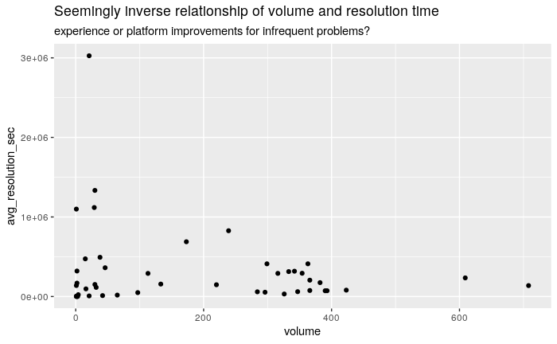

Looking at the box plots of resolution times between tickets over types we note that within interquartile range querries about complaints and finances take significantly longer to resolve.

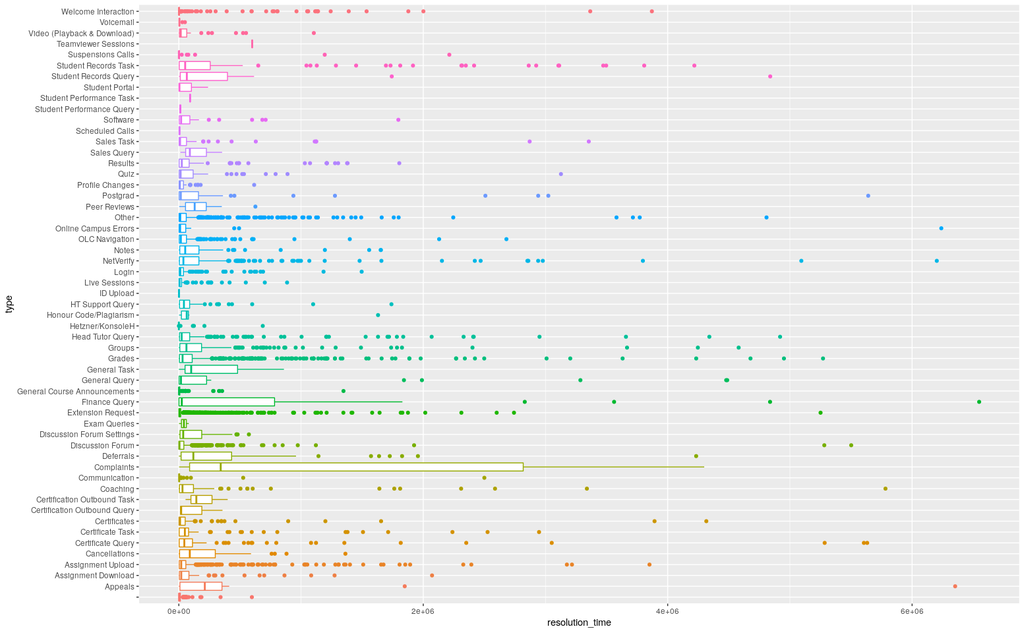

Looking at the average variation between agents however we see that the largest deviation between agents exists in;

- Student records
- Finance
- Complaints
- Certificates
- Appeals

Therefore we may want to improve methodology here so that resolution of these tickets are more predictable

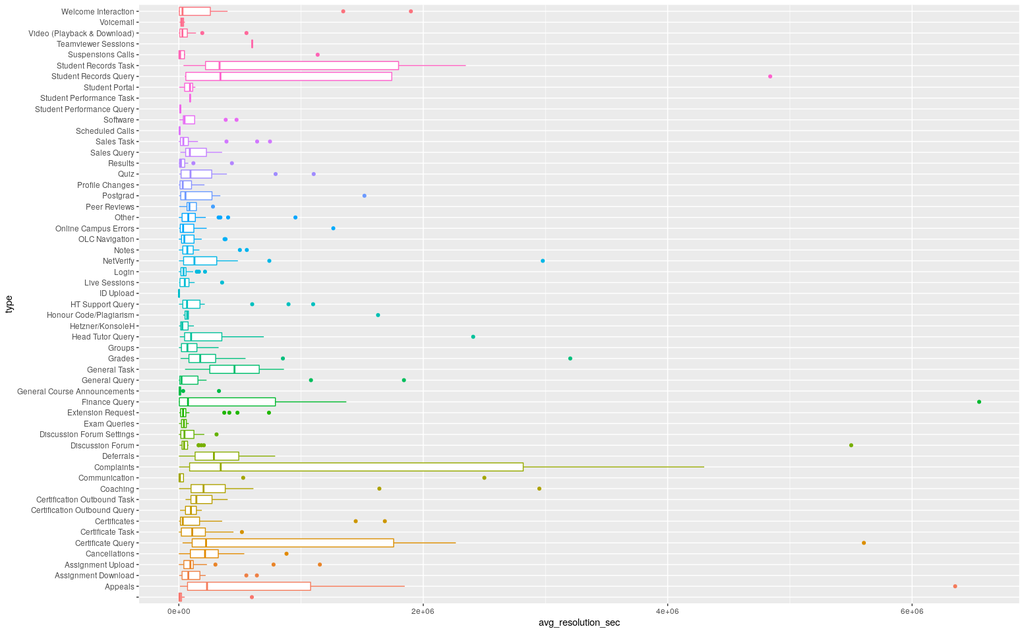

If we look at variation between agents instead the variation is slightly different.  
In particular for example; student record/certificate queries, complaints and finance querries’ time to resolution vary greatly between agents

One can also try to investigate the data yourself with some interactive widgets;

```r
library(plotly)
performance %>%
  highlight_key(~type) %>%
  plot_ly( x = ~volume, y = ~avg_resolution_sec, z = ~agent_id, color = ~type, hoverinfo="type") %>%
  add_markers() %>%
  highlight(on = "plotly_hover", off = "plotly_doubleclick")
```

We can take a closer look at the agents themselves and show their number of distinct types handles and the total average time they spend resolving tickets;

| agent_id | V1 | Appeals | Assignment Download | Assignment Upload | Cancellations | Certificate Query | Certificate Task | Certificates | Certification Outbound Query | Certification Outbound Task | Coaching | Communication | Complaints | Deferrals | Discussion Forum | Discussion Forum Settings | Exam Queries | Extension Request | Finance Query | General Course Announcements | General Query | General Task | Grades | Groups | Head Tutor Query | Hetzner/KonsoleH | Honour Code/Plagiarism | HT Support Query | ID Upload | … |
| --- | --- | --- | --- | --- | --- | --- | --- | --- | --- | --- | --- | --- | --- | --- | --- | --- | --- | --- | --- | --- | --- | --- | --- | --- | --- | --- | --- | --- | --- | --- |
| 1 | 22605.000 secs | NA secs | 638610.00 secs | 37521.82 secs | 109710.0 secs | NA secs | 516240.00 secs | 175110.00 secs | NA secs | NA secs | 51990.00 secs | 21540.0000 secs | NA secs | 483010.00 secs | 163534.62 secs | 308580.0 secs | NA secs | 59033.245 secs | NA secs | 11956.7647 secs | NA secs | 859980 secs | 155421.70 secs | 109200.00 secs | 144498.46 secs | NA secs | 1630020.00 secs | 41655.00 secs | NA secs | … |
| 2 | NaN secs | NA secs | NA secs | NA secs | NA secs | NA secs | NA secs | NA secs | NA secs | NA secs | NA secs | NA secs | NA secs | NA secs | NA secs | NA secs | NA secs | NA secs | NA secs | NA secs | 85680.00 secs | NA secs | NA secs | NA secs | NA secs | NA secs | NA secs | NA secs | NA secs | … |
| 3 | 22447.500 secs | NA secs | 86520.00 secs | 62445.93 secs | NA secs | NA secs | NA secs | 5840.00 secs | NA secs | NA secs | NA secs | NA secs | NA secs | NA secs | 60782.00 secs | 187071.4 secs | NA secs | 15945.945 secs | 68460 secs | 328380.0000 secs | 17460.00 secs | NA secs | 139550.00 secs | 21450.00 secs | 79287.69 secs | NA secs | NA secs | NA secs | 6180 secs | … |
| 4 | 9571.429 secs | 10440 secs | 165913.85 secs | 299397.14 secs | 275325.0 secs | NA secs | 109620.00 secs | 12120.00 secs | NA secs | NA secs | 347331.43 secs | NA secs | NA secs | NA secs | 79825.26 secs | NA secs | NA secs | 41820.330 secs | NA secs | 10740.0000 secs | NA secs | NA secs | 383656.44 secs | 76260.00 secs | 383400.00 secs | NA secs | NA secs | 37713.33 secs | NA secs | … |
| 5 | 12720.000 secs | NA secs | 12342.86 secs | 63836.67 secs | 79070.0 secs | NA secs | NA secs | 22720.00 secs | NA secs | NA secs | 197933.33 secs | NA secs | 2160 secs | 51917.14 secs | 43186.67 secs | 18210.0 secs | NA secs | 21144.459 secs | 420 secs | 255.0000 secs | NA secs | NA secs | 335250.00 secs | NA secs | 43301.74 secs | NA secs | NA secs | 212580.00 secs | NA secs | … |
| 6 | 1860.000 secs | NA secs | 77475.00 secs | 19557.39 secs | NA secs | NA secs | NA secs | 20978.18 secs | NA secs | NA secs | NA secs | NA secs | NA secs | NA secs | 34638.00 secs | 123450.0 secs | NA secs | 9410.964 secs | NA secs | 10931.8681 secs | NA secs | NA secs | 27148.80 secs | 11356.36 secs | 49028.57 secs | NA secs | NA secs | NA secs | NA secs | … |
| 7 | 2280.000 secs | 230790 secs | NA secs | 115389.23 secs | NA secs | NA secs | NA secs | 35550.00 secs | NA secs | NA secs | 610500.00 secs | NA secs | NA secs | 9420.00 secs | 12654.85 secs | 46020.0 secs | NA secs | 14480.092 secs | 600 secs | 9114.1463 secs | 7200.00 secs | NA secs | 118272.86 secs | 41460.00 secs | 289380.00 secs | 123300 secs | NA secs | 182460.00 secs | 660 secs | … |
| 8 | 12645.882 secs | NA secs | 552324.00 secs | 229937.65 secs | 138068.6 secs | NA secs | NA secs | 1830.00 secs | NA secs | NA secs | 104386.67 secs | 2499900.0000 secs | NA secs | 297746.40 secs | 38455.51 secs | NA secs | NA secs | 35758.105 secs | 2040 secs | 27276.8000 secs | NA secs | NA secs | 249205.16 secs | 219189.47 secs | 320501.25 secs | NA secs | 36140.00 secs | 144420.00 secs | NA secs | … |
| 9 | NaN secs | NA secs | NA secs | 1153980.00 secs | NA secs | NaN secs | NA secs | 1685740.00 secs | NA secs | NA secs | NA secs | NA secs | 3718380 secs | 788460.00 secs | NA secs | NA secs | NA secs | 371700.000 secs | NA secs | 1680.0000 secs | 1842000.00 secs | NA secs | 471573.33 secs | NA secs | NA secs | NA secs | NA secs | NA secs | NA secs | … |
| 10 | NaN secs | NA secs | 178740.00 secs | 58723.11 secs | NA secs | NA secs | NA secs | 32385.00 secs | NA secs | NA secs | NA secs | NA secs | NA secs | 192900.00 secs | 37977.39 secs | 91350.0 secs | NA secs | 13836.850 secs | 17400 secs | 16680.0000 secs | 240.00 secs | NA secs | 78555.00 secs | 120610.00 secs | 71766.00 secs | 2340 secs | 63240.00 secs | 139070.00 secs | NA secs | … |

[output cut: 39 more lines]

This table representing the high dimensionality of an agents interactions with tickets is difficult to visualize…

But it might reveal some interesting relationships between the resolution times of different ticket types over agents.

Let’s sort these tickets into different categories and see if we can measure relationships between types

Setup MFA analysis to investigate relationships in lower dim space

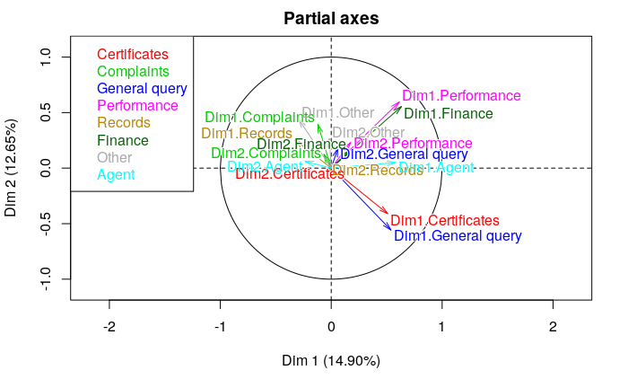

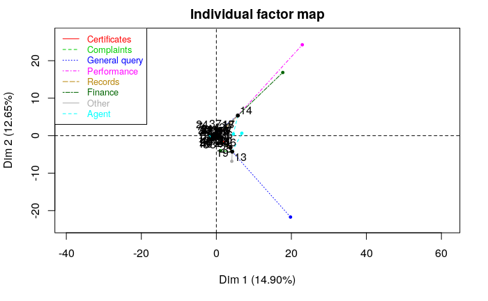

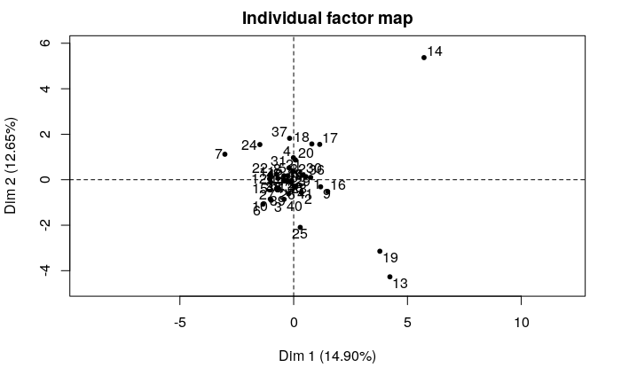

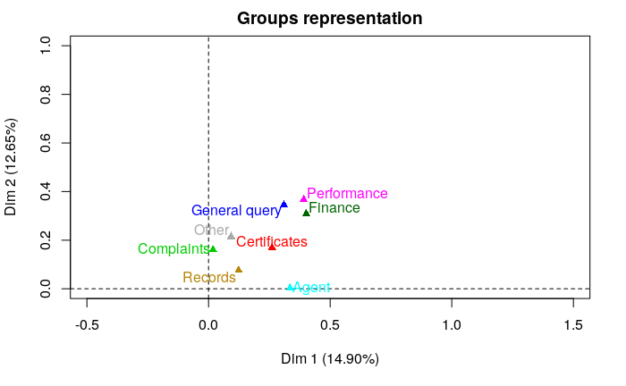

```r
library("FactoMineR")
library("factoextra")

group_sizes = c(5,6,19,7,6,2,10,2)
group_names = c('Certificates','Complaints','General query','Performance','Records','Finance','Other','Agent')
group_types = rep("c",length.out = length(group_names))

source('../src/visualization/MFA_c.R')
res.mfa <- MFA_c(mfa_df %>% map_df(as.numeric),
               group = group_sizes,
               type = group_types,
               name.group = group_names,
               ncp=2
               )
```

We can delve into this a little bit.

Group representation doesn’t show particularly distinct relationships;  
- Performance and Finance tickets are highly correlated  
- Could investigate relationship between complaints and agent volumes / resolution times (but we know this)  
- Certificates and general queries behave quite opposite to finance and performance querries (we know this, they resolve quickly)

On the other hand, the individuals plot of agents show that most agents are quite similar - with notable agents 13, 14 and 19 being outliers in some way.

This is interesting because we see in the box plots that resolution times for some ticket categories varies greatly between agents (e.g. complaints and records).

If agents are randomly allocated to tickets this may simply be inefficient.

On the other hand some ticket categories just take longer and vary more in general… Those should be revised and perhaps streamlined.

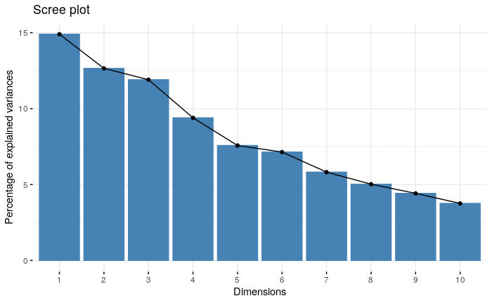

```r
res.mfa %>%
  fviz_screeplot
```

We should also be careful interpreting low dimensional representations since the eigenvalues don’t show a particularly high level of explained variance.

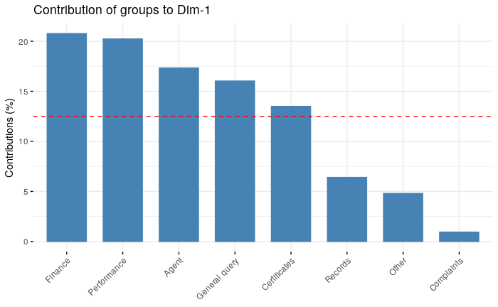

```r
fviz_contrib(res.mfa, "group", axes = 1)
```

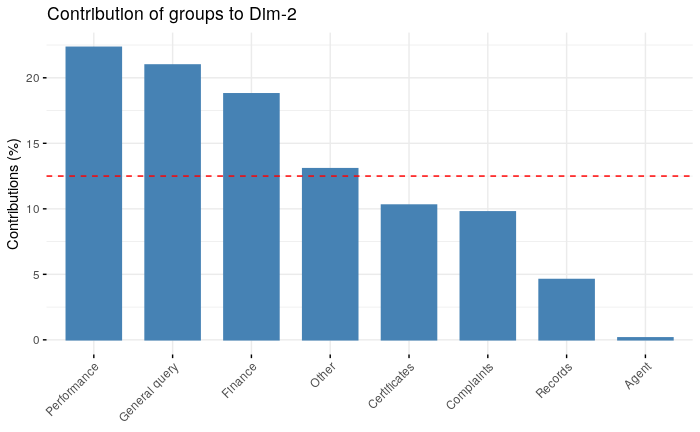

```r
# Contribution to the second dimension
fviz_contrib(res.mfa, "group", axes = 2)
```

The contribution plots also show that many types are similar in polar coordinates.

Let’s take a closer look between agents that score high on the 3 ticket groups;  
- Complaints  
- Finance/Performance  
- General querries

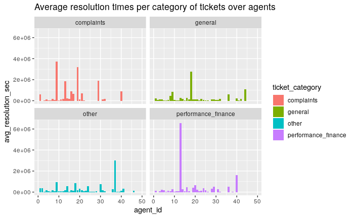

```r
category_data %>%
  ggplot()+
  geom_bar(aes(x=agent_id,y=avg_resolution_sec, fill = ticket_category),stat='identity')+
  facet_wrap(~ticket_category)+
  ggtitle("Average resolution times per category of tickets over agents")
```

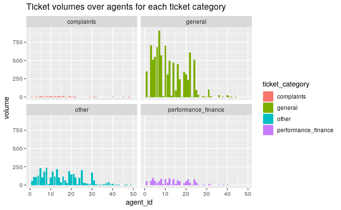

```r
category_data %>%
  ggplot()+
  geom_bar(aes(x=agent_id,y=volume, fill = ticket_category),stat='identity')+
  facet_wrap(~ticket_category)+
  ggtitle("Ticket volumes over agents for each ticket category")
```

This confirms the individuals plot of the MFA - most agents behave the same and are equally distributed between the different ticket categories. Also the outlier agents are likely due to outlier tickets that proved difficult to resolve.

When agents recieve complaints/finance/performance tickets they may take up a lot of time and reduce the volume of tickets these agents can address

## R test

### Import ticket data

```r
ticket_data201803 = data.table::fread("../data/raw/ticket_data201803 (1) (1).csv")
```

### Course CAM-BSM-2018-02-21 and >= 4 agent interactions

```r
ticket_data201803 %>%
  filter(agent_interactions > 3) %>%
  filter(course == 'CAM-BSM-2018-02-21')
```

| ticket_id | status | priority | source | group | created_time | resolved_time | initial_time | agent_interactions | customer_interactions | type | course | user_id | agent_id |
| --- | --- | --- | --- | --- | --- | --- | --- | --- | --- | --- | --- | --- | --- |
| 2014135 | Closed | Urgent | Email | Student Success | 2018-03-06 12:00 | 2018-03-08 16:32 | 2018-03-06 12:29 | 4 | 3 | Assignment Upload | CAM-BSM-2018-02-21 | 2774 | 7 |
| 2134291 | Closed | Urgent | Email | Student Success | 2018-03-27 17:35 | 2018-04-05 12:21 | 2018-03-28 00:30 | 5 | 5 | Extension Request | CAM-BSM-2018-02-21 | 1014 | 8 |
| 2089118 | Closed | Low | Email | Student Success | 2018-03-19 17:55 | 2018-03-20 16:54 | 2018-03-19 22:07 | 4 | 1 | Head Tutor Query | CAM-BSM-2018-02-21 | 1443 | 21 |
| 2048726 | Closed | Urgent | Email | Student Success | 2018-03-12 14:01 | 2018-03-13 16:28 | 2018-03-12 14:09 | 6 | 9 | Head Tutor Query | CAM-BSM-2018-02-21 | 292 | 21 |
| 2058637 | Closed | Urgent | Email | Student Success | 2018-03-14 01:14 | 2018-03-19 13:00 | 2018-03-14 08:50 | 7 | 9 | Results | CAM-BSM-2018-02-21 | 652 | 21 |
| 2048984 | Closed | Urgent | Email | Student Success | 2018-03-12 14:42 | 2018-03-13 08:50 | 2018-03-12 15:06 | 7 | 5 | Assignment Upload | CAM-BSM-2018-02-21 | 49 | 21 |
| 2001239 | Resolved | Urgent | Email | Student Success | 2018-03-04 17:04 | 2018-04-17 08:39 | 2018-03-04 18:13 | 5 | 3 | Other | CAM-BSM-2018-02-21 | 1728 | 21 |
| 2111788 | Closed | Urgent | Email | Student Success | 2018-03-23 07:16 | 2018-03-30 13:37 | 2018-03-23 09:55 | 4 | 2 | Deferrals | CAM-BSM-2018-02-21 | 1167 | 21 |
| 2097650 | Closed | Urgent | Email | Student Success | 2018-03-20 21:14 | 2018-03-22 08:48 | 2018-03-21 09:36 | 4 | 5 | Head Tutor Query | CAM-BSM-2018-02-21 | 49 | 21 |
| 2022777 | Closed | Urgent | Email | Student Success | 2018-03-07 14:27 | 2018-04-06 13:08 | 2018-03-07 14:47 | 8 | 8 | Coaching | CAM-BSM-2018-02-21 | 1884 | 21 |

[output cut: 21 more lines]

### Customer interactions GS-ID-2018-02-15

```r
ticket_data201803 %>%
  filter(course == 'GS-ID-2018-02-15') %>%
  pull(customer_interactions)
```

```
 [1]  1  2  1  1 NA  1  1 NA  1  1  9  1  1  1  4 NA  1 NA  1  1  2  1  1 NA  1  4  4  6  2  3  2  1  1
```

### Replace NA’s of previous

```r
ticket_data201803 %>%
  filter(course == 'GS-ID-2018-02-15') %>%
  pull(customer_interactions) %>%
  replace_na(replace = mean(., na.rm = T))
```

```
 [1] 1 2 1 1 2 1 1 2 1 1 9 1 1 1 4 2 1 2 1 1 2 1 1 2 1 4 4 6 2 3 2 1 1
```